# HCH8

```r
knitr::opts_knit$set(root.dir = '~/Documents/SFSU.FALL.2017/424/R/R/Exercises&Examples')
```

4,11,20,26

Question 4 U dataset: MOISSANITE

1. Calculate the regression residuals.
2. Plot the residuals against x. Do you detect a trend?
3. Propose an alternative model based on the plot, part b.
4. Fit and analyze the model you proposed in part c.

```r
setwd("~/Documents/SFSU.FALL.2017/424/R/R/Exercises&Examples")
load("MOISSANITE.Rdata")
View(MOISSANITE)
```

1. calculate residuals

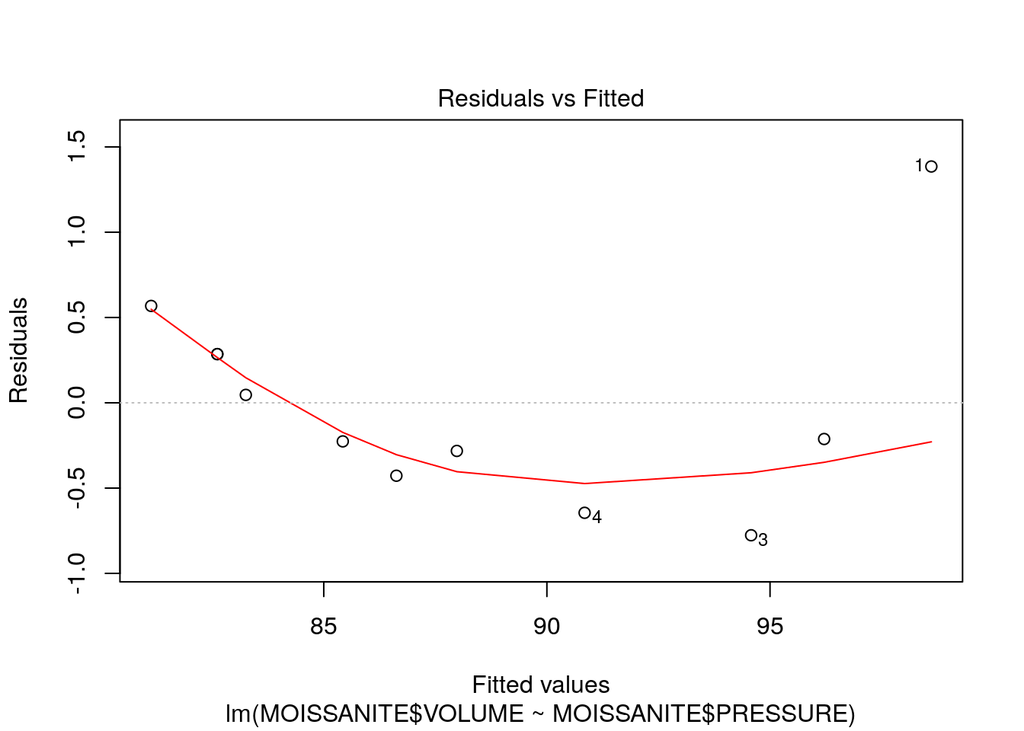

```r
model = lm(MOISSANITE$VOLUME~MOISSANITE$PRESSURE)
plot(model, which = 1:1)
```

```r
residuals(model)
```

```
##           1           2           3           4           5           6
##  1.38508113 -0.21233184 -0.77652790 -0.64485018 -0.28219329 -0.42754316
##           7           8           9          10          11
## -0.22624964  0.04630246  0.28528837  0.28528837  0.56773568
```

```r
sum(residuals(model))
```

```
## [1] -1.554312e-15
```

After plotting the residuals of the model, the plot of FItted values vs Residuals, we can see that there is a trend in the residuals and instead of being linear, appears to be quadratic.

The new proposed model is $E(y)=\hat\beta_0 + \hat\beta_1x_1 + \hat\beta_2x_1^2$ Testing this:

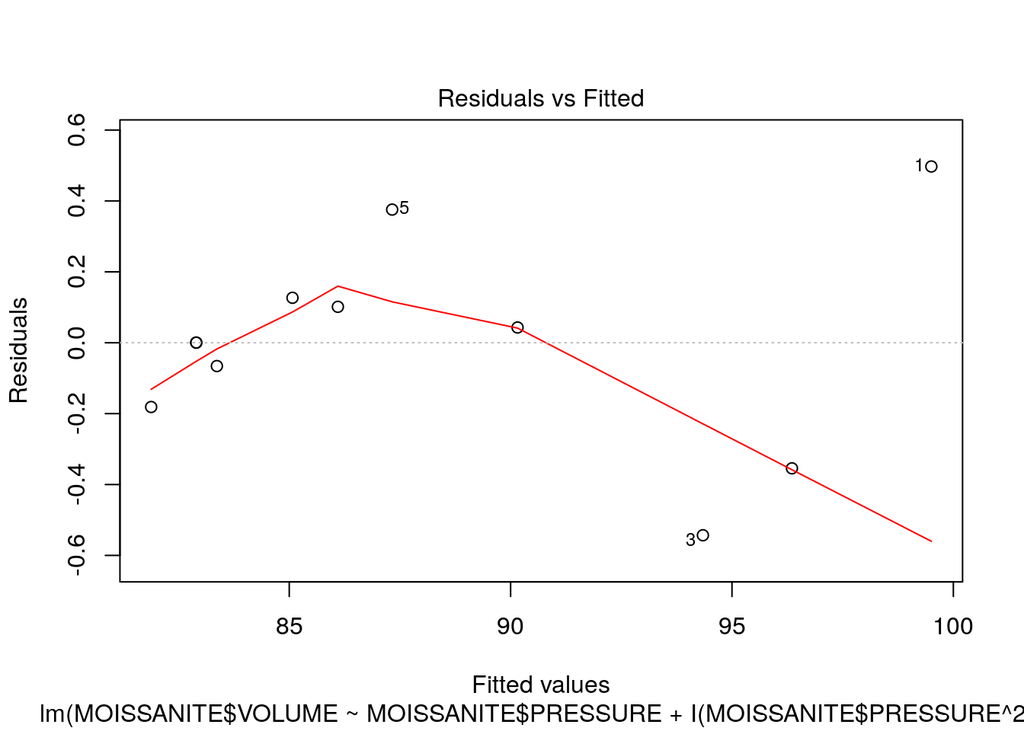

```r
model2 = lm(MOISSANITE$VOLUME~MOISSANITE$PRESSURE+I(MOISSANITE$PRESSURE^2))
plot(model2,which = 1:1)
```

Question 11

E(y) = β 0 + β 1 x 1 + β 2 x 2 + β 3 x 1 x 2 . Fit the model to the data saved in the GASTURBINE file, then plot the residuals against predicted heat rate. Is the assumption of a constant error variance reasonably satisfied? If not, suggest how to modify the model.

```r
load("GASTURBINE.Rdata")
View(GASTURBINE)
heatrate= GASTURBINE$HEATRATE
rpm = GASTURBINE$RPM
cpratio = GASTURBINE$CPRATIO
model = lm(heatrate~cpratio+rpm+I(cpratio*rpm))
summary(model)
```

```
##
## Call:
## lm(formula = heatrate ~ cpratio + rpm + I(cpratio * rpm))
##
## Residuals:
##     Min      1Q  Median      3Q     Max
## -1211.7  -375.6  -107.2   189.7  2095.0
##
## Coefficients:
##                    Estimate Std. Error t value Pr(>|t|)
## (Intercept)       1.207e+04  4.185e+02  28.828  < 2e-16 ***
## cpratio          -1.461e+02  2.666e+01  -5.479 7.98e-07 ***
## rpm               1.697e-01  3.467e-02   4.895 7.16e-06 ***
## I(cpratio * rpm) -2.425e-03  3.120e-03  -0.777     0.44
## ---
## Signif. codes:  0 '***' 0.001 '**' 0.01 '*' 0.05 '.' 0.1 ' ' 1
##
## Residual standard error: 633.8 on 63 degrees of freedom
## Multiple R-squared:  0.8492, Adjusted R-squared:  0.8421
## F-statistic: 118.3 on 3 and 63 DF,  p-value: < 2.2e-16
```

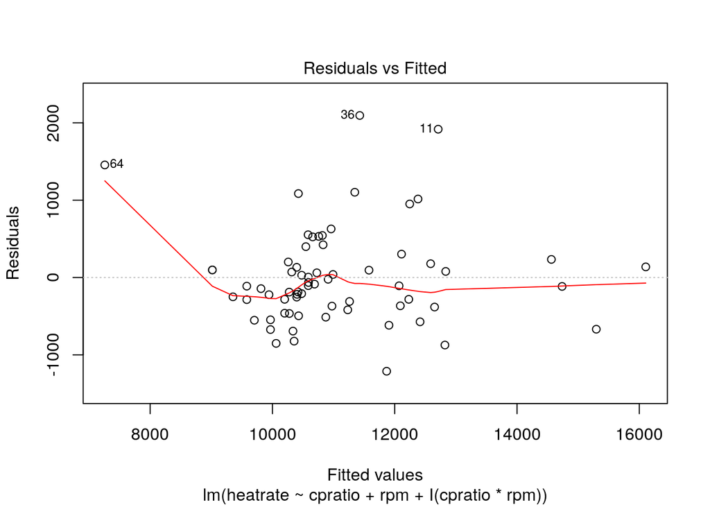

```r
plot(model, which = 1:1)
```

Quesstion 20

The Normal Q-Q plot is displayed below. The chart compares the standardized residuals with the quartiles that should be theoretically exist.

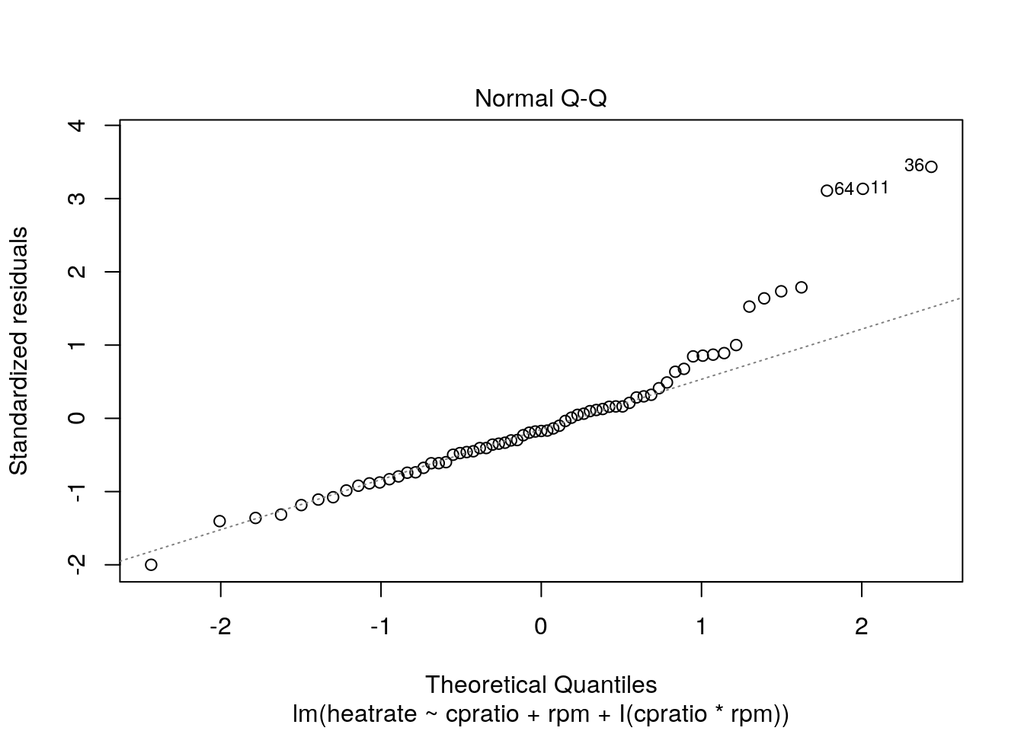

```r
model = lm(heatrate~cpratio+rpm+I(cpratio*rpm))
plot(model, which = 2:2)
```

Here, we graph the residuals versus the expected residuals under the assumption of normality. If we assume normality, then we expect to see a near straight line from plotting th two against eachother. Failing to see this would be akin to a proof by contradiction. We assume the plot will be a straight line and see if the shows us otherwise. In this case, excluding the 3 extreme outliers, 11,36,64, this can be viewed as sufficiently normal.

```r
GASTURBINE
```

| ENGINE | SHAFTS | RPM | CPRATIO | INLETTEMP | EXHTEMP | AIRFLOW | POWER | HEATRATE | LHV | ISOWORK |
| --- | --- | --- | --- | --- | --- | --- | --- | --- | --- | --- |
| Traditional | 1 | 27245 | 9.2 | 1134 | 602 | 7 | 1630 | 14622 | 24.6 | 232.86 |
| Traditional | 1 | 14000 | 12.2 | 950 | 446 | 15 | 2726 | 13196 | 27.3 | 181.73 |
| Traditional | 1 | 17384 | 14.8 | 1149 | 537 | 20 | 5247 | 11948 | 30.1 | 262.35 |
| Traditional | 1 | 11085 | 11.8 | 1024 | 478 | 27 | 6726 | 11289 | 31.9 | 249.11 |
| Traditional | 1 | 14045 | 13.2 | 1149 | 553 | 29 | 7726 | 11964 | 30.1 | 266.41 |
| Traditional | 1 | 6211 | 15.7 | 1172 | 517 | 176 | 52600 | 10526 | 34.2 | 298.86 |
| Traditional | 1 | 6210 | 17.4 | 1177 | 510 | 193 | 57500 | 10387 | 34.7 | 397.93 |
| Traditional | 1 | 3600 | 13.5 | 1146 | 503 | 315 | 89600 | 10592 | 34.0 | 284.44 |
| Traditional | 1 | 3000 | 15.1 | 1146 | 524 | 375 | 113700 | 10460 | 34.4 | 303.20 |
| Traditional | 1 | 3000 | 15.0 | 1171 | 525 | 514 | 164300 | 10086 | 35.7 | 319.65 |

[output cut: 57 more lines]

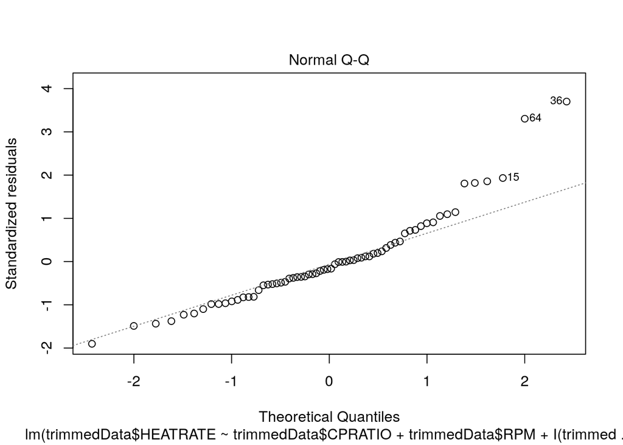

```r
trimmedData = GASTURBINE[-11,]
model = lm(trimmedData$HEATRATE~trimmedData$CPRATIO+trimmedData$RPM+I(trimmedData$CPRATIO*trimmedData$RPM), data = trimmedData)
plot(model, which = 2:2)
```

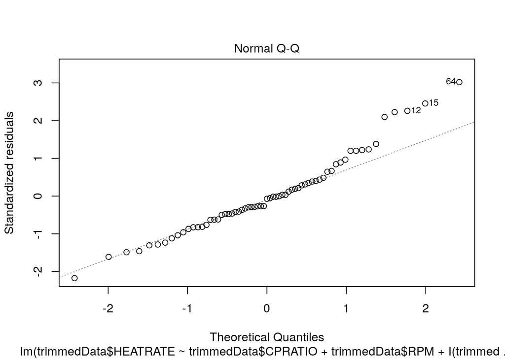

```r
trimmedData = GASTURBINE[c(-11,-36),]
model = lm(trimmedData$HEATRATE~trimmedData$CPRATIO+trimmedData$RPM+I(trimmedData$CPRATIO*trimmedData$RPM), data = trimmedData)
plot(model, which = 2:2)
```

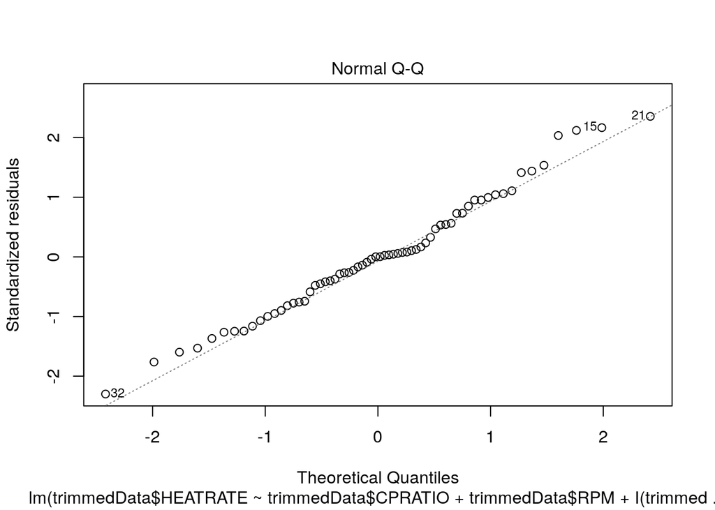

```r
trimmedData = GASTURBINE[c(-11,-36, -64),]
model = lm(trimmedData$HEATRATE~trimmedData$CPRATIO+trimmedData$RPM+I(trimmedData$CPRATIO*trimmedData$RPM), data = trimmedData)
plot(model, which = 2:2)
```

Question 26

```r
load("GFCLOCKS.Rdata")
View(GFCLOCKS)
```